# **Insertion Sort**

## Algortima Isertion Sort

Pada algoritma insertion sort, diasumsikan bahwa sebagian data sudah dalam keadaan terurut (pada posisi sebelah kiri dari data list), sehingga data berikutnya akan dibandingkan dengan data yang sudah dalam keadaan terurut ini, dan disisipkan (insertion) pada bagian data yang sudah terurut tersebut. Dengan konsep seperti ini, posisi sebelah kiri dari list data (sebelum ada data baru yang akan disisipkan), selalu dalam keadaan terurut.

Berikut ilustrasi insertion sort (ascending). Misalkan terdapat data yang memiliki nilai [7, 2.5, 5, 10, 1].

**Iterasi Pertama**. Pada iterasi pertama, diasumsikan indeks ke-0, adalah data yang sudah dalam keadaan terurut. Data yang digunakan sebagai **key**, adalah data indeks ke-1. Langkah berikutnya adalah menyisipkan key pada kumpulan data terurut sebelumnya, sehingga data saat ini menjadi [2.5, 7, 5, 10, 1]. Akhir dari iterasi pertama adalah, data pada indeks ke-0 dan indeks ke-1, sudah dalam keadaan terurut. Ilustrasi ini dapat dilihat pada Gambar 1.

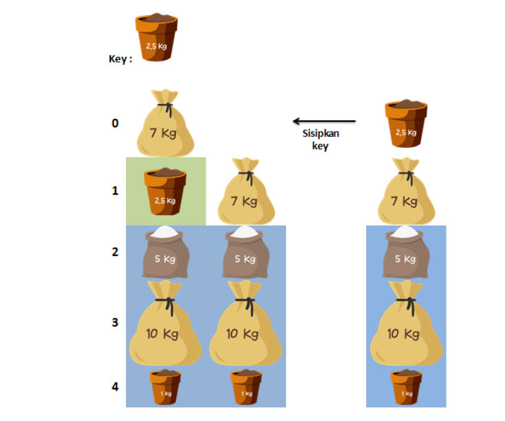

**Gambar 1. Iterasi Pertama Algoritma Insertion Sort**

**Iterasi Kedua**. Pada iterasi kedua menjadikan data pada indeks ke-2, yaitu 5, menjadi **key**. Sehingga pada iterasi kedua ini, berusaha menyispikan key pada kumpulan data terurut sebelumnya, yaitu [2.5, 7], dengan cara membandingkan satu persatu. Karena nilai key lebih kecil dari 7, dan lebih besar dari 2.5, maka key disisipkan diantara kedua nilai tersebut, sehingga data setelah iterasi kedua, menjadi [2.5, 5, 7, 10, 1]. Dapat dilihat bahwa data indeks ke-0, sampai dengan indeks ke-2, sudah dalam keadaan terurut. Ilustrasi ini dapat dilihat pada Gambar 2.

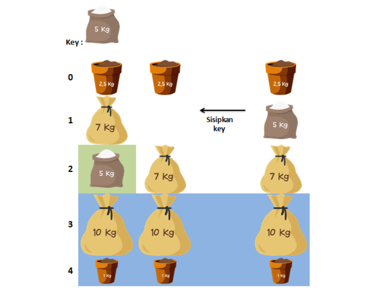

**Gambar 2. Iterasi Kedua Algoritma Insertion Sort**

**Iterasi Ketiga**. Key pada iterasi ketiga adalah data pada indeks ke-3, yaitu 10. Tujuan akhir dari iterasi ketiga adalah mencari lokasi yang tepat untuk data 10 diantara data yang sudah urut sebelumnya, yaitu [2.5, 5, 7]. Karena perbandingan pertama yang dilakukan adalah dengan data 7, dan 10 > 7, maka data 10 berada pada tempat yang sama. Ilustrasi iterasi ketiga ini, dapat dilihat pada Gambar 3.

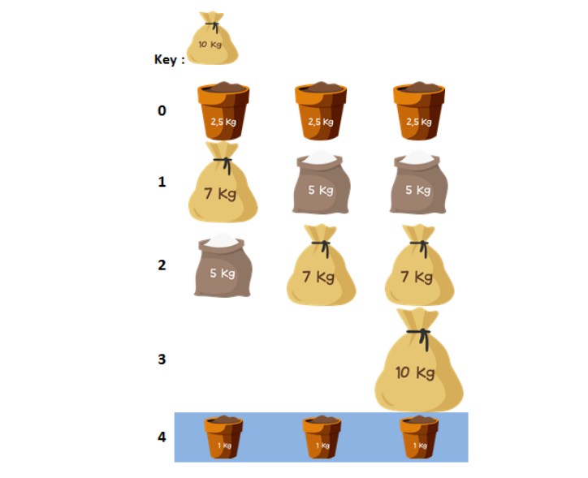

**Gambar 3. Iterasi Ketiga Algoritma Insertion Sort**

**Iterasi Keempat**. Key untuk iterasi keempat adalah data pada indeks ke-4, yaitu 1. Pada iterasi keempat ini bertujuan untuk menyisipkan data 1 pada data yang sudah dalam keaadan urut sebelumnya, yaitu [2.5, 5, 7, 10]. Perbandingan dilakukan sebanyak empat kali untuk mencari posisi yang tepat untuk data 1 ini. Sehingga data 1 harus disisipkan, sebelum data 2.5. Ilustrasi ini dapat dilihat pada Gambar 4.

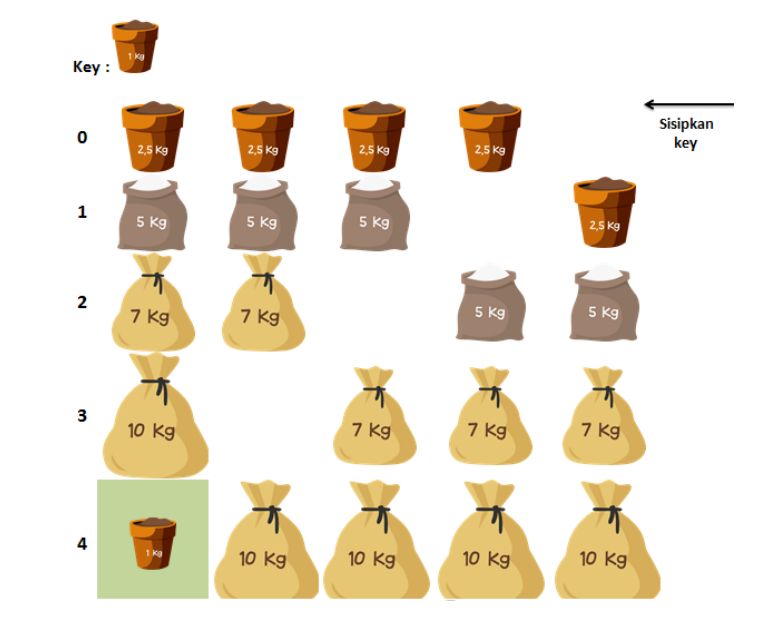

**Gambar 4. Iterasi Keempat Algoritma Insertion Sort**

Akhir dari iterasi keempat ini adalah data sudah dalam keaadan terurut, seperti yang ditunjukkan pada Gambar 5.

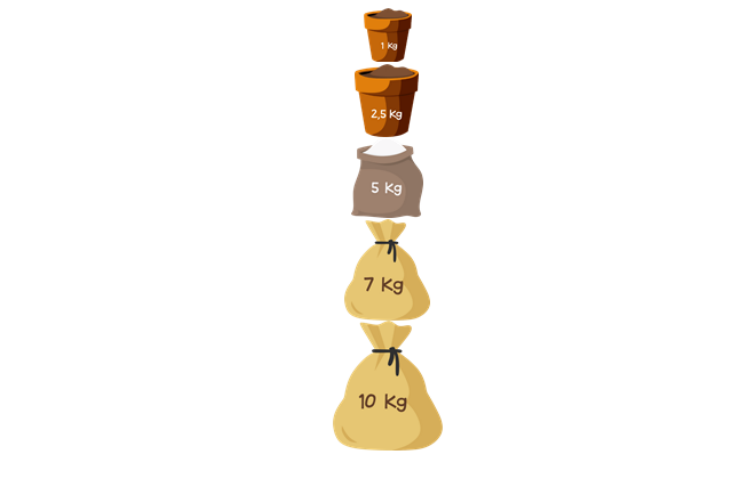

# **Code**

Berikut code untuk pengurutan dengan menggunakan algoritma Insertion Sort. Iterasi dalam, menggunakan iterasi while, karena iterasi akan berhenti atau tidak dikerjakan, ketika nilai pada key lebih dari data terakhir yang akan dibandingkan.

```python
def insertionSort(listData):
    for outIter in range(1,len(listData)):
        print(listData)
        key=listData[outIter]
        ind=outIter
        while (ind>0 and listData[ind-1]>key):
            listData[ind]=listData[ind-1]
            ind=ind-1
            print('inner=',listData)
        listData[ind]=key

    print('sortedData=',listData)
```

```python
# b=[10,2,5,8]
b=[3, 2, 1]
insertionSort(b)
```

```
[3, 2, 1]
inner= [3, 3, 1]
[2, 3, 1]
inner= [2, 3, 3]
inner= [2, 2, 3]
sortedData= [1, 2, 3]
```

# **Latihan Mandiri**

```python
def insertionSort(listData):
    for outIter in range(1,len(listData)):
        print(listData)
        key=listData[outIter]
        ind=outIter
        swapp = False
        while (ind>0 and listData[ind-1]>key):
            listData[ind]=listData[ind-1]
            ind=ind-1
            print('inner=',listData)
            swapp = True
        listData[ind]=key

        if not swapp:
            return "List sudah terurut"
            break

    print('sortedData=',listData)
```

```python
b=[3, 5, 9, 12, 14, 15, 19]
insertionSort(b)
```

```
[3, 5, 9, 12, 14, 15, 19]
```

```
'List sudah terurut'
```

**1.** Urutkan data dengan insertion sort.

Misalkan kita memiliki data: `[4, 3, 2, 10, 12, 1, 5, 6]`. Algoritma ini membagi data menjadi dua bagian: bagian yang **sudah terurut** (di sebelah kiri) dan **belum terurut** (di sebelah kanan).

- **Awal:** Anggap elemen pertama `[4]` sudah terurut.
- **Langkah 1:** Ambil `3`. Sisipkan sebelum `4`. Hasil: `[3, 4, 2, 10, ...]`
- **Langkah 2:** Ambil `2`. Sisipkan sebelum `3`. Hasil: `[2, 3, 4, 10, ...]`
- **Langkah 3:** Ambil `10`. Posisinya sudah benar setelah `4`. Hasil: `[2, 3, 4, 10, 12, ...]`
- Dan seterusnya hingga elemen terakhir disisipkan ke posisi yang tepat.

**2.** Program insertion sort ascending

```python
def insertion_sort_ascending(arr):
    # Mulai dari indeks 1 karena indeks 0 dianggap sudah terurut
    for i in range(1, len(arr)):
        key = arr[i] # Elemen yang akan disisipkan
        j = i - 1

        # Pindahkan elemen-elemen yang lebih besar dari 'key' ke kanan
        while j >= 0 and key < arr[j]:
            arr[j + 1] = arr[j]
            j -= 1

        # Sisipkan 'key' pada posisi yang tepat
        arr[j + 1] = key

    return arr

data1 = [12, 11, 13, 5, 6]
print("Ascending :", insertion_sort_ascending(data1))
```

```
Ascending : [5, 6, 11, 12, 13]
```

**3.** Program insertion sort descending

```python
def insertion_sort_descending(arr):
    for i in range(1, len(arr)):
        key = arr[i]
        j = i - 1

        # Ubah tanda menjadi > agar elemen yang lebih KECIL dari 'key' yang dipindah ke kanan
        while j >= 0 and key > arr[j]:
            arr[j + 1] = arr[j]
            j -= 1

        arr[j + 1] = key

    return arr

data2 = [12, 11, 13, 5, 6]
print("Descending:", insertion_sort_descending(data2))
```

```
Descending: [13, 12, 11, 6, 5]
```

**4.** Jelaskan analogi kartu

Insertion sort sangat mirip dengan cara orang mengurutkan kartu remi di tangannya.

1. Anda memegang kartu di tangan kiri yang pada awalnya kosong, dan setumpuk kartu di meja menghadap ke bawah.
2. Anda mengambil satu kartu dari meja menggunakan tangan kanan.
3. Anda menyisipkan (insert) kartu tersebut ke posisi yang benar di antara kartu-kartu yang sudah ada di tangan kiri Anda.
4. Untuk menemukan posisi yang tepat, Anda membandingkan kartu baru tersebut dengan kartu-kartu di tangan Anda dari kanan ke kiri.

**5.** Proses pergeseran elemen

Dalam kodenya, proses pergeseran terjadi di dalam loop `while`. Jika kita sedang mencoba menyisipkan elemen `key` (misalnya angka 5), kita mengecek angka-angka di sebelah kirinya. Jika ada angka yang lebih besar dari 5 (misalnya 12), kita tidak menukarnya secara langsung. Kita **menggeser** angka 12 tersebut satu langkah ke kanan (`arr[j + 1] = arr[j]`). Pergeseran ini terus dilakukan sampai ditemukan angka yang lebih kecil dari 5 atau batas kiri array tercapai. Tempat kosong yang tersisa akibat pergeseran itulah yang akan diisi oleh elemen `key`.

**6.** Perbedaan dengan seletion sort.

Meskipun keduanya membagi array menjadi bagian terurut dan belum terurut:

- **Selection Sort:** Mencari elemen **terkecil/terbesar** di seluruh sisa array yang belum terurut, lalu menaruhnya di akhir bagian yang sudah terurut. Fokusnya pada proses *pencarian*.
- **Insertion Sort:** Mengambil elemen **pertama** dari bagian yang belum terurut, lalu menyusuri bagian yang sudah terurut untuk *menyisipkannya* di posisi yang tepat. Fokusnya pada proses *pergeseran* dan *penyisipan*.

**7.** Pseudocode insertsion sort.

Berikut adalah pseudocode untuk Insertion Sort (Ascending):

```
FOR i = 1 TO n-1 DO
    key = arr[i]
    j = i - 1

    WHILE j >= 0 AND arr[j] > key DO
        arr[j+1] = arr[j]
        j = j - 1
    END WHILE

    arr[j+1] = key
END FOR
```

**8.** Kapan digunakan?

Insertion Sort sangat efektif dan disarankan untuk digunakan ketika:

1. **Jumlah data sedikit** (karena tidak memerlukan alokasi memori tambahan yang kompleks).
2. **Data sudah hampir terurut** (*nearly sorted*). Dalam kondisi ini, Insertion Sort sangat cepat (mendekati $O(N)$) karena hanya memerlukan sedikit pergeseran elemen.
3. Algoritma ini sering digunakan sebagai bagian dari algoritma pengurutan yang lebih canggih (seperti Timsort pada Python atau variasi Quick Sort) ketika memecah data menjadi array-array berukuran sangat kecil.